# Examen Final

Curso IE0217 Estructuras abstractas y algoritmos para ingeniería - UCR

Profesor Freddy Rojas Ch.

# Examen Final

## Enunciado

En el GIT de cada estudiante existe una una *rama* con el nombre *pyExamenFinal_3_2020*.

Dentro de esta instancia se encuentra una carpeta con el nombre *ExamenFinal* que a su vez contiene la sub-carpeta *Data* con información para resolver el examen.

Pueden usar *Eclipse* haciendo el proyecto dentro de una carpeta del área GIT similar a como se desarrollaron las tareas de manera que estén sincronizados con GIT y con Eclipse.

Manteniendo la línea de trabajo de las últimas tareas en este examen final se van a realizar estudios de agrupamientos con información Covid-19. En la carpeta *Data* se encuentran estos dos archivos:

*time_series_covid19_confirmed_global.csv*

*time_series_covid19_recovered_global.csv*

#### Exploracion y clusterización del Covid-19

Al igual que en las tareas 04 y 05 donde se hizo un recorrido por los datos contenidos en el sitio oficial de información covid-19 mundial en el examen final se solicitará realizar estudios de clusterización según las intruccciones que se muestran a continuación.

La fuente de fue obtenida del sitio:

*COVID-19 Data Repository by the Center for Systems Science and Engineering (CSSE) at Johns Hopkins University*

URL= *https://github.com/CSSEGISandData/COVID-19*

Este examen es generado en forma aleatoria y es diferente al examen de los demás estudiantes, en todos los casos se solicita realizar varios pasos para concluir el examen.

Los datos solicitados asociados a los países con los que se realizarán los estudios son diferentes para cada estudiante.

Las métodos solicitados a evaluar también cambian según el estudio, así como los gráficos pedidos.

El examen se abre a las 5:00 p.m. del 3 de marzo del 2021 y el profesor mantendrá consultas abiertas sobre el enunciado hasta las 6:00 p.m.

El tiempo de entrega del examen es a las 12:00 media noche.

Para la recepción del examen se utilizará el reservorio GIT en la rama *pyExamenFinal_3_2020*, indicada y se debe depositar en la carpeta *ExamenFinal*.

### Datos de referencia

Los datos en el directorio contemplan registros que van desde el 22 de Enero del 2020 hasta la fecha de actualización en marzo 2 del 2021

### Planteamiento

#### Parte 1.

Deben colocar este archivo (HTML) en el GIT con el fin de confrontar las respuestas con el enunciado. Recuerden que cada enunciado de cada estudiante es diferente.

Deben hacer el *stage*, el *comit* indicando inicio de examen. Luego el *push* para que el profesor pueda confirmar la primera descarga.

### Parte 2 Archivo a utilizar y conjunto de datos

Para este examen debe utilizar únicamente la siguiente información:

```
## Archivo a utilizar:  time_series_covid19_recovered_global.csv
```

```
## Conjunto de paises a utilizar:
```

```
## ['Peru', 'Chile', 'Paraguay', 'Uruguay', 'Brazil', 'Colombia', 'Venezuela', 'Ecuador', 'Argentina', 'Bolivia']
```

### Parte 3 Procedimiento de lectura y filtrado del archivo (No evaluado )

La parte 3 corresponde a material de aopyo y NO SERA EVALUADO como parte de la nota final.

Para facilidad de la carga y ajuste inicial de los archivos, se ofrece el siguiente segmento de código que les permite leer el archivo y extraer los países en las filas y las columnas con las fechas para todos los paises.

El resultado es una dataframe de nombre DF que contienen la información leida. Nótese que se están usando los valores diarios absolutos (differencia) y no el acumulado diario, tal cual es el archivo original. Para ello pueden observar el uso del método **diff** en el código entregado.

#### Código de apoyo

```python
import numpy as np
import pandas as pd
import prince


import matplotlib.pyplot as plt
import seaborn as sns

from   sklearn.cluster import KMeans

class ProceseArchivo():
  def CargarArchivo(self,nombrearchivo):
    self.__df=pd.read_csv(nombrearchivo, delimiter=',',decimal=".")
    return True

  def ReducirDataFrame(self,columnas):
    df_reducido=self.__df.drop(  self.__df.columns[columnas],axis=1)
    return df_reducido

  def VisualizarDatos(self):
    print("Contenido de archivo leido")
    print(self.__df.iloc[0:8,0:5])
    print("\nNombres de las columnas (variables)")
    print(self.__df.columns)
    print("\nNombres de los primeros 10 países")
    nombres=self.__df.iloc[:,1]
    print(nombres[0:10])

  def ProcesarDatos(self,NombreArchivo,Indice,ColumnasBorrar):
    if not self.CargarArchivo(NombreArchivo):
      return False
    self.VisualizarDatos()
    df_reducido=self.ReducirDataFrame(ColumnasBorrar)
    df_reducido=df_reducido.set_index(Indice)
    #
    df_reducido=df_reducido.diff(axis=1)
    df_reducido=df_reducido.drop(df_reducido.columns[0],axis=1)
    #
    df_reducido=df_reducido.groupby(df_reducido.index).agg(lambda m:sum(m))
    return df_reducido
```

Este código es sugerido. De usarlo deben incluirlo en la solución entregada.

En caso de escoger otro código este debe ser incluido en la entrega final y debe correr correctamente.

##### Nota

Al usar el código debe cambiar la variable *xpath* de manera que ubique sus archivos y las variables *filas* con los paises y *filename_eval* con el nombre del archivo.

En este código se coloca el subdirectorio *Data* en el área de trabajo.

```python
#______________________ MAIN __________
Procesar=ProceseArchivo()
xpath="./Data/"
indice="Country/Region"
ColumnsToDelete=[0]+ list(range(2,4))    # Se eliminarán en todos los archivos las columnas 0,2,3
DF=Procesar.ProcesarDatos(xpath+filename_eval,indice,ColumnsToDelete)
```

```
## Contenido de archivo leido
##   Province/State       Country/Region       Lat       Long  1/22/20
## 0            NaN          Afghanistan  33.93911  67.709953        0
## 1            NaN              Albania  41.15330  20.168300        0
## 2            NaN              Algeria  28.03390   1.659600        0
## 3            NaN              Andorra  42.50630   1.521800        0
## 4            NaN               Angola -11.20270  17.873900        0
## 5            NaN  Antigua and Barbuda  17.06080 -61.796400        0
## 6            NaN            Argentina -38.41610 -63.616700        0
## 7            NaN              Armenia  40.06910  45.038200        0
##
## Nombres de las columnas (variables)
## Index(['Province/State', 'Country/Region', 'Lat', 'Long', '1/22/20', '1/23/20',
##        '1/24/20', '1/25/20', '1/26/20', '1/27/20',
##        ...
##        '2/20/21', '2/21/21', '2/22/21', '2/23/21', '2/24/21', '2/25/21',
##        '2/26/21', '2/27/21', '2/28/21', '3/1/21'],
##       dtype='object', length=409)
##
## Nombres de los primeros 10 países
## 0            Afghanistan
## 1                Albania
## 2                Algeria
## 3                Andorra
## 4                 Angola
## 5    Antigua and Barbuda
## 6              Argentina
## 7                Armenia
## 8              Australia
## 9              Australia
## Name: Country/Region, dtype: object
```

```python
print("Archivo reducido para resolver el examen:")
```

```
## Archivo reducido para resolver el examen:
```

```python
print(DF)
```

```
##                     1/23/20  1/24/20  1/25/20  ...  2/27/21  2/28/21  3/1/21
## Country/Region                                 ...
## Afghanistan               0        0        0  ...        3       45      11
## Albania                   0        0        0  ...      962      804     640
## Algeria                   0        0        0  ...      134      122     136
## Andorra                   0        0        0  ...       35       17      29
## Angola                    0        0        0  ...        8        7      78
## ...                     ...      ...      ...  ...      ...      ...     ...
## Vietnam                   0        0        0  ...        5       32       0
## West Bank and Gaza        0        0        0  ...      914      817     808
## Yemen                     0        0        0  ...        1        0       0
## Zambia                    0        0        0  ...      974      889     589
## Zimbabwe                  0        0        0  ...       51       76     239
##
## [192 rows x 404 columns]
```

La salida anterior contempla como filas los nombres de los países y como columnas las fechas. Se contemplan todos los países.

### Parte 4. Examen.

Estos son los puntos que deben desarrollar como parte del examen final.

#### Parte 4 procedimiento 1 separación de países. *(10%)*

Deben separar los países solicitados del resto del *data frame* de manera que se genere un nuevo conjunto de esta forma:

*Debe aportar el código y la salida de este punto*

```
## Selección de paises
```

```
## ['Peru', 'Chile', 'Paraguay', 'Uruguay', 'Brazil', 'Colombia', 'Venezuela', 'Ecuador', 'Argentina', 'Bolivia']
```

```
## Data frame para procesar:
```

```
##                 1/23/20  1/24/20  1/25/20  ...  2/27/21  2/28/21  3/1/21
## Country/Region                             ...
## Peru                  0        0        0  ...     7586        0    6533
## Chile                 0        0        0  ...     4004     3575    3683
## Paraguay              0        0        0  ...      984      990     957
## Uruguay               0        0        0  ...      454      573     585
## Brazil                0        0        0  ...    61880    10868   55295
## Colombia              0        0        0  ...     3576     2799    3384
## Venezuela             0        0        0  ...      455        0     813
## Ecuador               0        0        0  ...        0     9081       0
## Argentina             0        0        0  ...     6253     5934    6317
## Bolivia               0        0        0  ...      603      479     620
##
## [10 rows x 404 columns]
```

### Parte 4 procedimiento 2 *(30%)*

1. Deben realizar el análisis utilizando K-medias (KMeans) la bibliotecha from s_klearn_ a partir de los datos contenidos en el *data frame* generado en el punto anterior.

La biblioteca se carga de esta manera:

```python
from   sklearn.cluster import KMeans
```

Para realizar la clusterización deben ajustar la tabla de manera que la agrupación se realiza sobre las fechas y las variables observadas son los países.

a.1) Realice la clusterización con K medias con 3 grupos. Debe imprimir la forma de la tabla resultante y los datos de la predicción de cada grupos y los centros. (Refererse a clases y tareas)

*Debe aportar el código y la salida de este punto*

```
## KMeans(n_clusters=3)
```

a.2) Realice el gráfico de barras con las columnas de los países agrupados.(Refererse a clases y tareas).

*Debe aportar el código y la salida de este punto*

*Los gráficos a generar son similares a estos*

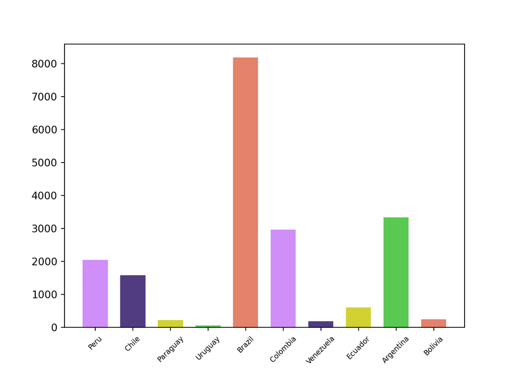

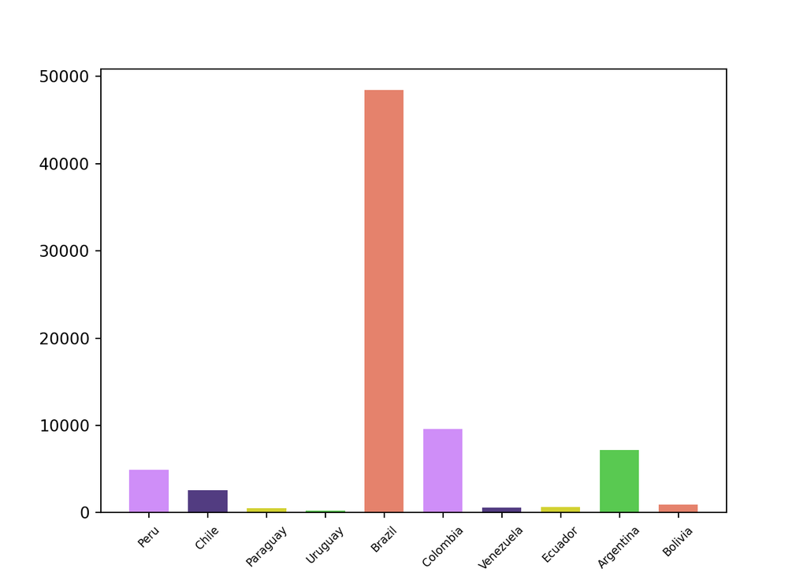

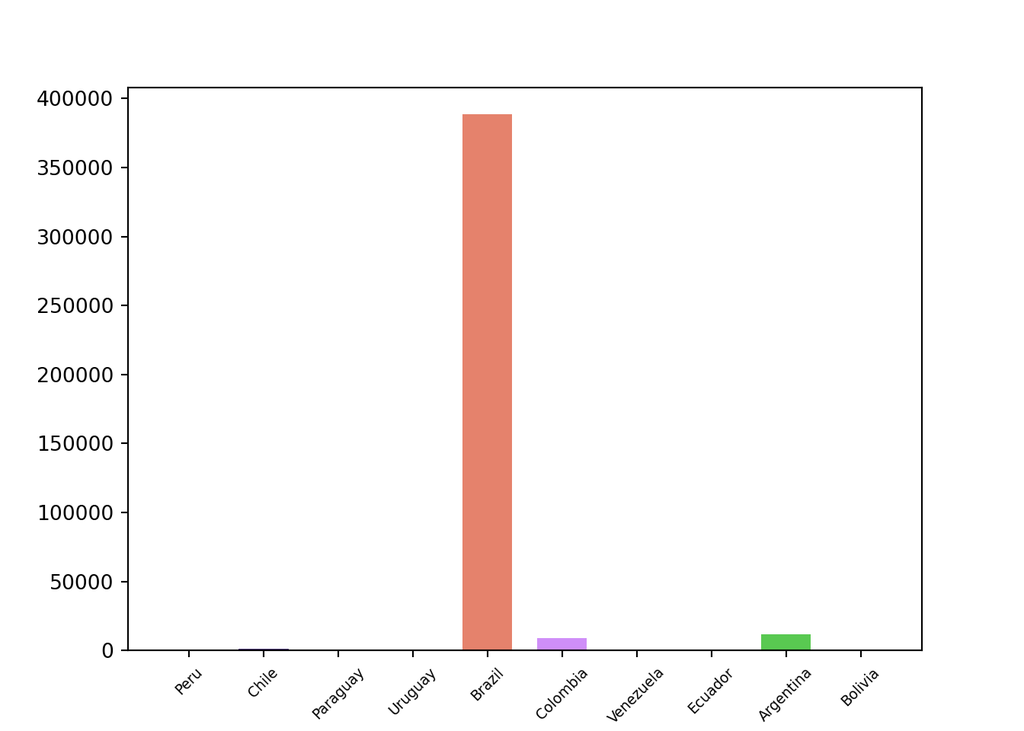

¿Cúal es su interpretación de estos resultados?

### Parte 4 procedimiento 3 *(40%)*

2. Anáisis K Medias a valores medios.

Se desea agrupar las fechas en forma discreta en tres “clustes”. En otras palabras, se harán grupos de fechas y para cada grupo los pesos porcentuales de los centros usando K-medias se realizarán sobre los países. De esta manera se harán gráficos en que se observa el peso porcentual de cada país a cada uno de los “clusters”.

b.1) Para el análisis de valores medios se requiere que las variables sigan siendo los países y las observaciones correspondan a la fechas.

b.2) Deben agregrar dos columnas con el mes (“mes_x”) y año (“year_x”) tomando la fecha para obtener los valores numéricos del mes y el año.

*Debe aportar el código y la salida de este punto*

b.3) Deben agrupar por mes y año de manea que se observe para cada país el VALORES MEDIO DIARIO de casos para cada combinación mes/año. De manaera que la salida una vez calculado el valor medio contiene como variables los países y las observaciones corresponden a los valores medios diarios para cada mes en cada año.

El *data frame* debe ser similar a esta

*Debe aportar el código y la salida de este punto*

```
## Country/Region         Peru        Chile  ...     Argentina      Bolivia
## month_x year_x                            ...
## 1       2020       0.000000     0.000000  ...      0.000000     0.000000
##         2021    3249.419355  3374.161290  ...   9515.290323   875.000000
## 2       2020       0.000000     0.000000  ...      0.000000     0.000000
##         2021    6212.321429  3519.607143  ...   6548.964286  1207.500000
## 3       2020      12.709677     5.032258  ...      7.741935     0.000000
##         2021    6533.000000  3683.000000  ...   6317.000000   620.000000
## 4       2020     333.700000   280.800000  ...     33.866667     4.400000
## 5       2020    1832.354839  1101.516129  ...    131.612903    26.967742
## 6       2020    3577.566667  6616.733333  ...    556.400000   279.066667
## 7       2020    3528.387097  2809.612903  ...   1992.000000   459.419355
## 8       2020    5533.612903  1792.000000  ...   7013.387097  1187.935484
## 9       2020    7382.266667  1757.000000  ...   9781.666667  1170.700000
## 10      2020    4690.032258  1614.612903  ...  12235.290323   515.290323
## 11      2020    2358.166667  1332.066667  ...   9442.933333   339.966667
## 12      2020    1879.258065  1638.000000  ...   5466.096774   335.322581
##
## [15 rows x 10 columns]
```

b.4) Con este *data frame* resultante deben agrupar nuevamente usando K-medias (KMeans) y mostrar los centros hacer de nuevo los gráficos de barras del caso inicial pero con este nuevo conjunto de datos.

*Debe aportar el código y la salida de este punto*

```
## KMeans(n_clusters=3)
```

*Los gráficos a generar son similares a estos*

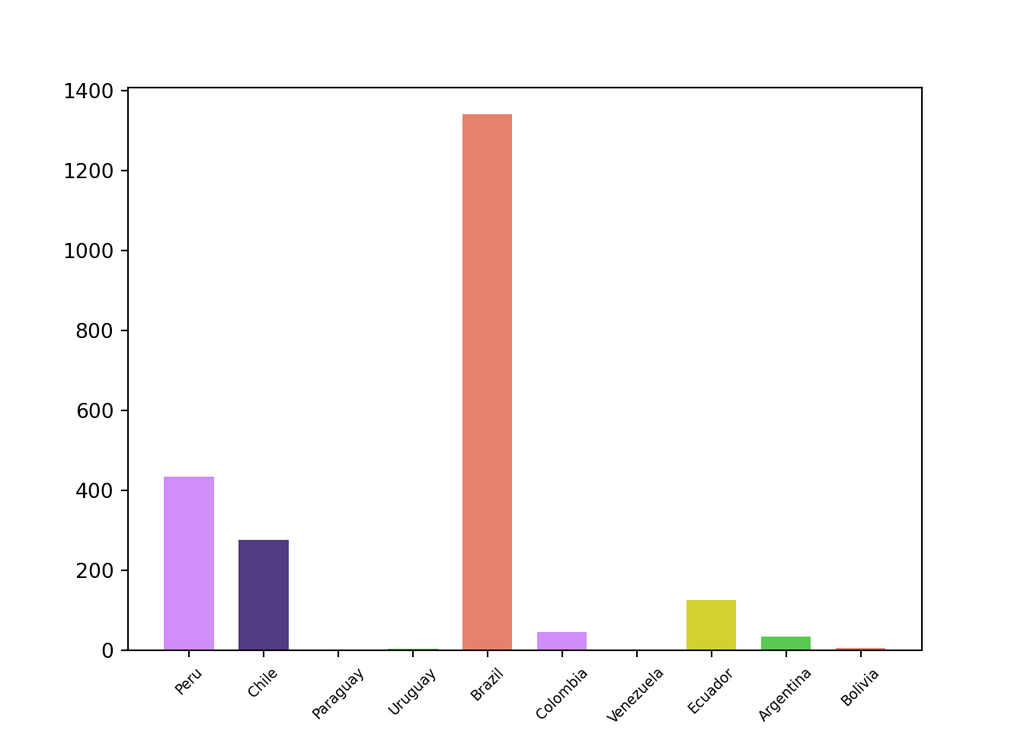

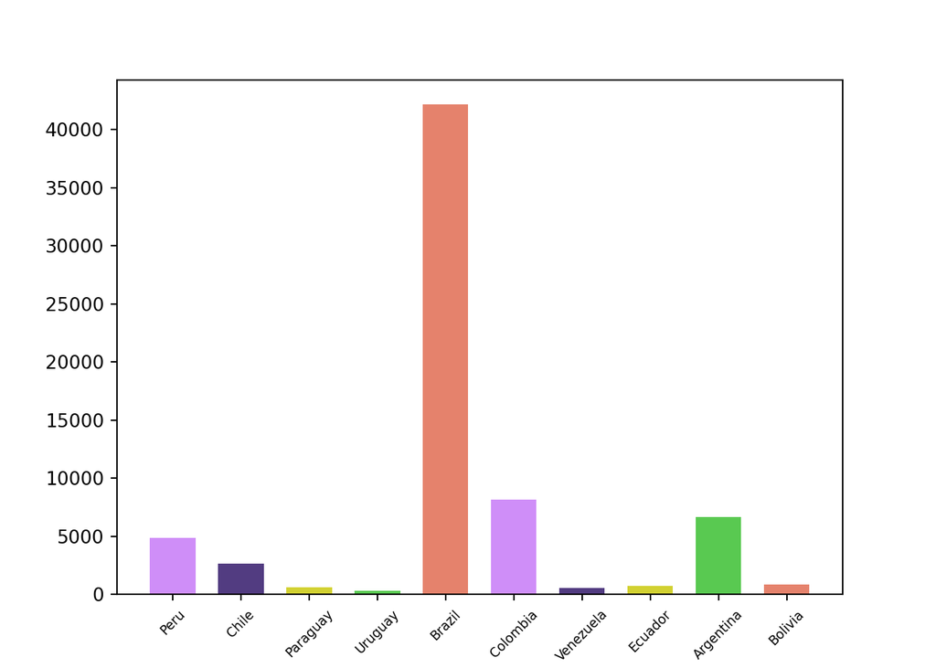

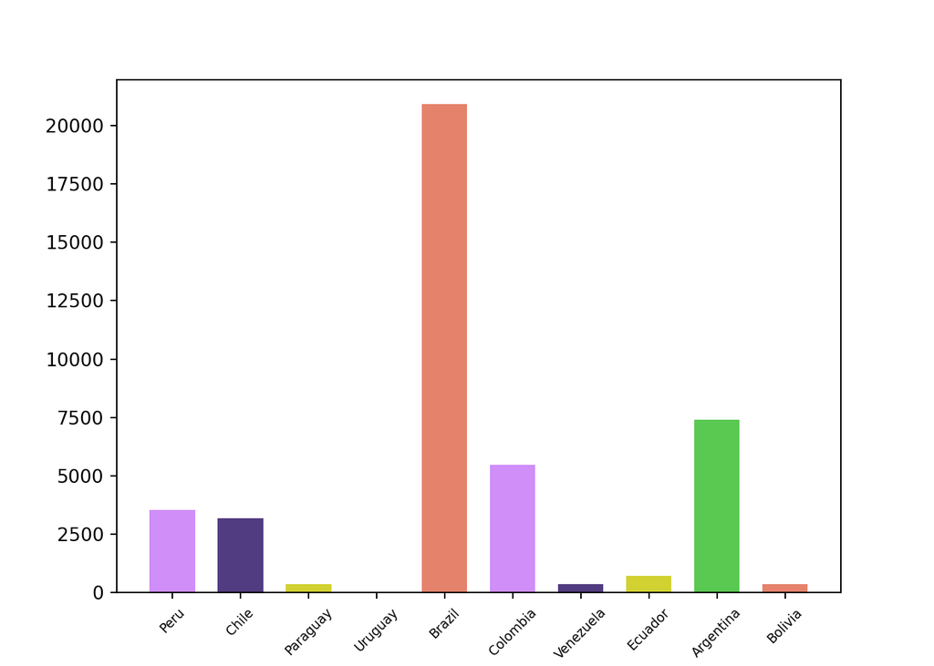

b.5) Cuales son las conclusiones que da esta información con respecto al análsis con K-medias (KMeans) anterior.

### Parte 4 procedimiento 4 *(20%)*

3. Generar gráficos.

c.1) Hacer el gráfico de correlaciones de los datos consolidados por mes. Nota los valores para la correlación serán los datos usados en K-medias (KMeans) normalizados según se incluye en la solución de las tareas.

*Debe aportar el código y la salida de este punto*

*El gráfico a generar es similar a este*

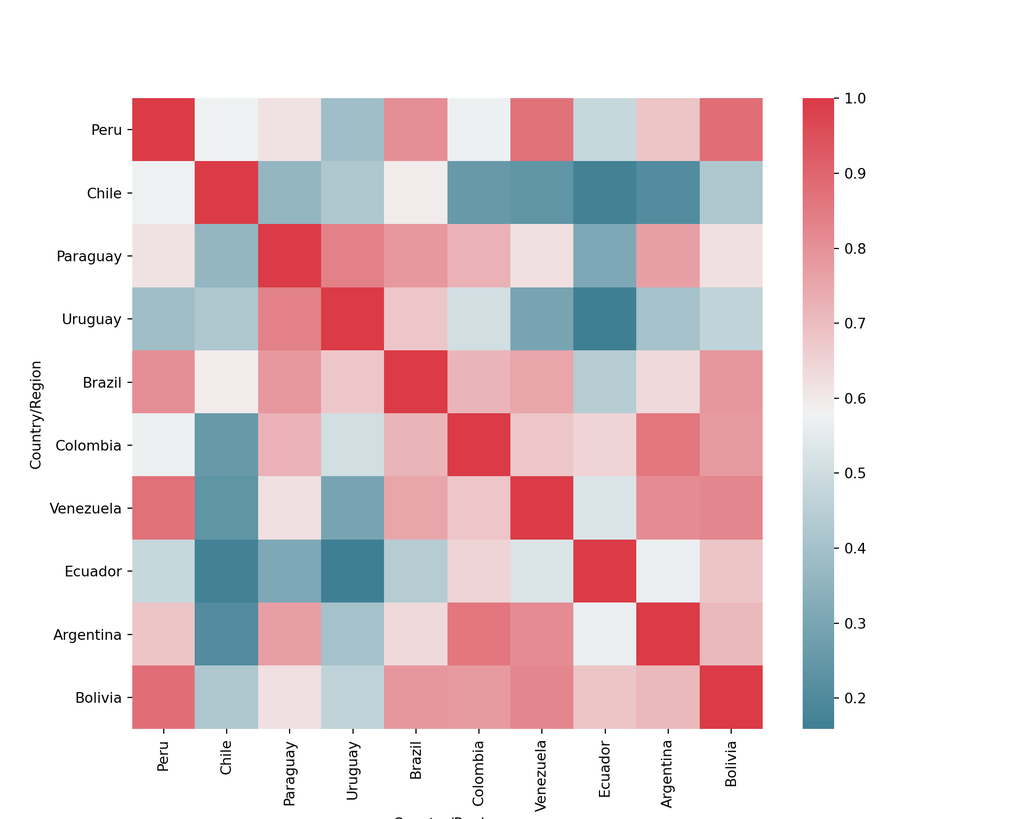

Hay concordancia de las correlaciones y el K-medias (KMeans) de ambos análisis?

c.2) Hacer el gráfico boxplot de los valores medios sumarizados.

*Debe aportar el código y la salida de este punto*

*El gráfico a generar es similar a este*

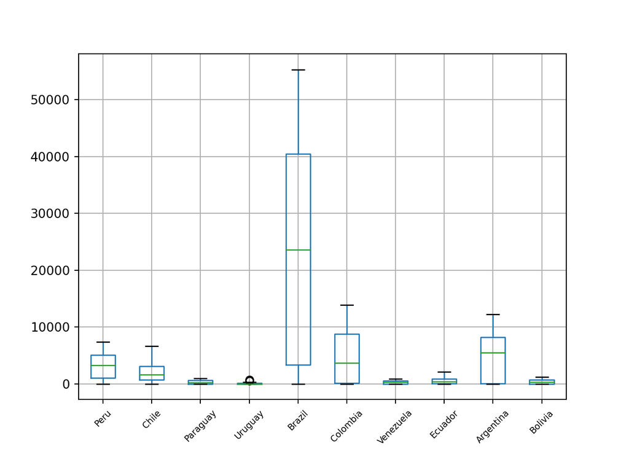

Qué concluye de este gráfico